# User Manual: IgGeneUsage

SK

June 25, 2019

# 1 Introduction

Decoding the properties of the immune repertoires is key in understanding the response of adaptive immunity during health challenges such as infection or disease. One important feature of all repertoires is their gene usage, i.e. the frequency at which the various germline genes have been rearranged to generate diverse B and T cell receptors (BCRs and TCRs).

If we discover a disruption in gene usage under a specific biological condition compared to a control, we can use this as hint about the potential link between that condition (disease, virus, etc.) and the immune mechanisms that for BCR/TCR generation and rearrangement, including subsequent selection pressures.

The first step is, however, to detect differential gene usage between two biological conditions (e.g. healthy vs tumor). IgGeneUsage can help you do that.

# 2 Usage

All you need to carry out your analysis with IgGeneUsage is a data.frame with the following 4 columns:

1. sample_id: character identifier of the sample/repertoire (e.g. Patient-1)
2. condition: character identifier of the condition to which each repertoire belongs (e.g. healthy or tumor)
3. gene_name: specific gene name (e.g. IGHV1-10 or family TRVB1)
4. gene_usage_count: numeric (count) of rearrangements related to columns 1-3

Important remarks:

- the sum of the gene_usage_count (column 4) for a given sample (sample_id) should be equal to the total number of rearrangements in that repertoire.
- the remaining parameters provided to IgGeneUsage help the MCMC sampler. The default settings should suffice for most analyses.

# 3 Case Studies

## 3.1 Case Study I

The IgGeneUsage package comes with built-in datasets of gene usage. In the first case study we will evaluate disruptions in the IGHV-segment usage of class switched (CS) memory B-cells between HCV+ (N = 22) and healthy individuals (N = 7).

Tucci, Felicia A., et al. “Biased IGH VDJ gene repertoire and clonal expansions in B cells of chronically hepatitis C virus–infected individuals.” Blood 131.5 (2018): 546-557.]

### 3.1.1 Input data

| sample_id | condition | gene_name | gene_usage_count |
| --- | --- | --- | --- |
| HD1 | healthy | IGHV1-18 | 69 |
| HD1 | healthy | IGHV4-30-2 | 16 |
| HD1 | healthy | IGHV7-4-1 | 0 |
| HD1 | healthy | IGHV3-19 | 1 |
| HD1 | healthy | IGHV3-33 | 110 |
| HD1 | healthy | IGHV3-69-1 | 4 |

### 3.1.2 Data visualization

Lets look at the input data with ggplot2.

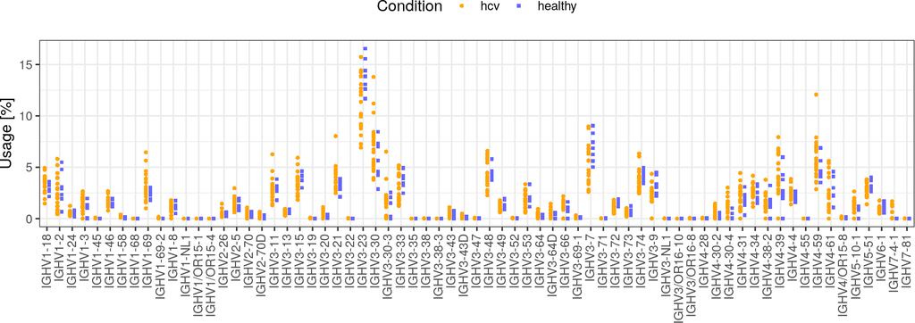

### 3.1.3 Analysis with IgGeneUsage

This is the main method of IgGeneUsage for differential gene usage.

### 3.1.4 Model checking

Do not blindly trust the model $\rightarrow$ check it extensively.

- Checklist of successful MCMC sampling:

  https://mc-stan.org/misc/warnings.html
  - no divergences
  - no additional warnings from rstan
  - Rhat < 1.05 (see object glm.stats)
  - sufficiently high Neff
- Checklist for valid model:
  - posterior predictive check reveal decent predictive accuracy on already observed data (and also new data)
  - leave-one-out analysis with R-package loo (most k values should be low)

#### 3.1.4.1 Checking MCMC sampling

- divergences, tree-depth, energy

```
FALSE
FALSE Divergences:
FALSE
FALSE Tree depth:
FALSE
FALSE Energy:
```

- Rhat and Neff

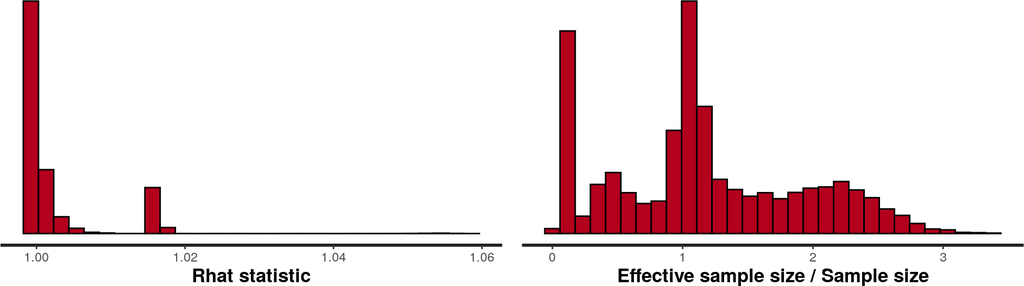

#### 3.1.4.2 Repertoire-specific PPC

- IgGeneUsage performs automatic posterior predictive check (PPC).
- In the following figure, we show the predictions (y-axis) of the model for the usage of each gene (shown as point) in a given repertoire. The predictions are compared against the observed data (x-axis).
- If the point lies on the the diagnoal $\rightarrow$ accurate prediction.

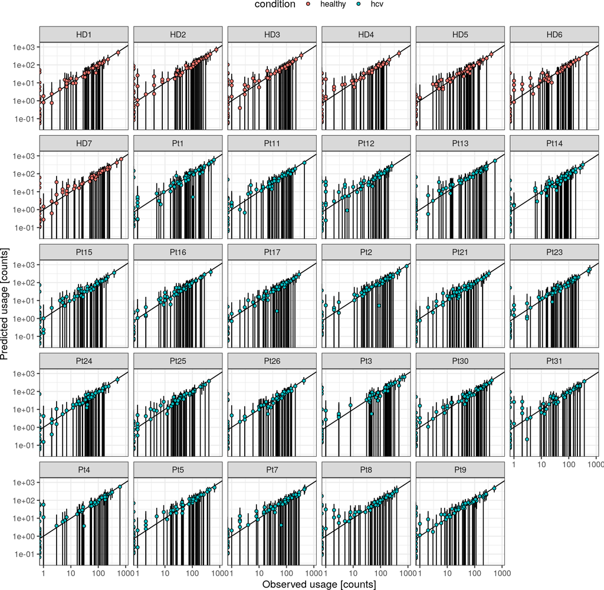

#### 3.1.4.3 Gene-specific PPC

- IgGeneUsage performs automatic posterior predictive check (PPC) at level of genes as well, i.e. , predicts the overal (pooled) usage of a gene within each condition.
- Legend:
  - x-axis: mean usage of repertoires with given condition
  - y-axis: predicted usage (with 95% HDI)
- If the point lies on the the diagnoal $\rightarrow$ accurate prediction.
- In the previous plot, the usage data and the predictions consist counts. In this plot, the usage is shown as % usage.

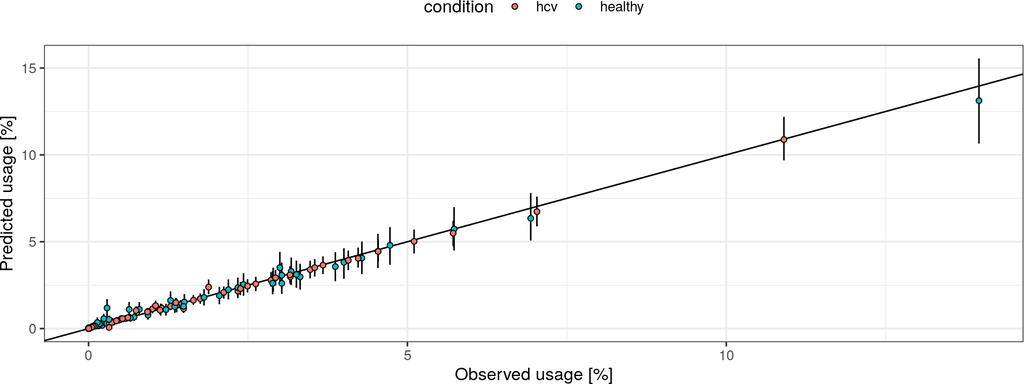

#### 3.1.4.4 Leave-one-out based comparison

- with R-package loo

```
FALSE
FALSE Computed from 4000 by 2001 log-likelihood matrix
FALSE
FALSE          Estimate    SE
FALSE elpd_loo  -6686.3 101.9
FALSE p_loo       527.4  24.1
FALSE looic     13372.6 203.7
FALSE ------
FALSE Monte Carlo SE of elpd_loo is NA.
FALSE
FALSE Pareto k diagnostic values:
FALSE                          Count Pct.    Min. n_eff
FALSE (-Inf, 0.5]   (good)     1382  69.1%   370
FALSE  (0.5, 0.7]   (ok)        396  19.8%   117
FALSE    (0.7, 1]   (bad)       202  10.1%   21
FALSE    (1, Inf)   (very bad)   21   1.0%   2
FALSE See help('pareto-k-diagnostic') for details.
```

### 3.1.5 Results

This following figure shows the main result of IgGeneUsage $\rightarrow$ disruption effects on each gene due to the biological condition. On the y-axis we show the probability of differential usage ($\pi$) in different genes shown as points. The names of genes with $\pi > 0.95$ are shown.

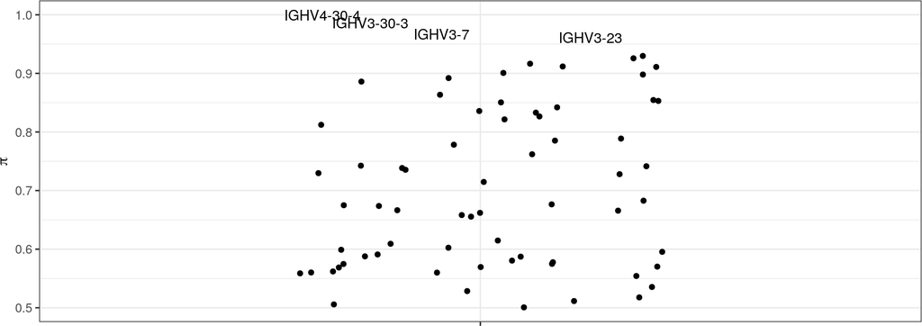

#### 3.1.5.1 Promising results [%]

Lets visualize the raw data of the genes with promising probability of differential gene usage ($\pi > 0.95$).

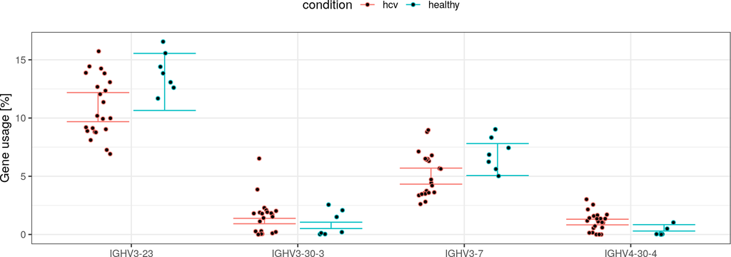

#### 3.1.5.2 Promising results [count]

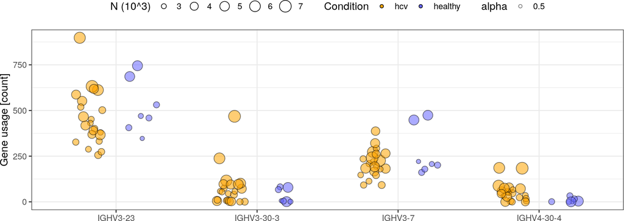

#### 3.1.5.3 Comparison with the t-test

Despite the fact that both assumptions made by the t-test are violated, i.e. (1) the assumption of normally distributed data and (2) homoscedasticity, the t-test if often used in the literature for differential gene usage analysis. To use the t-test, researchers compute the usage proportions (and not the raw counts). With that, they discard data about the sample size. Here, we nevertheless compare our results against p-values obtained with a t-test (with assumption of unequal variance). These statistics are automatically estimated by IgGeneUsage.

The following figure compares the effect sizes obtained from the Bayesian analysis with the p-values obtained from the t-test. Legend:

- y-axis: FDR-corrected p-value shown on -log10 scale. Dashed lines represent the significance levels of 0.05 and 0.01.
- x-axis: probability of differential gene usage

We can notice a few deviations between the two analyses. Lets inspect the corresponding genes more closely.

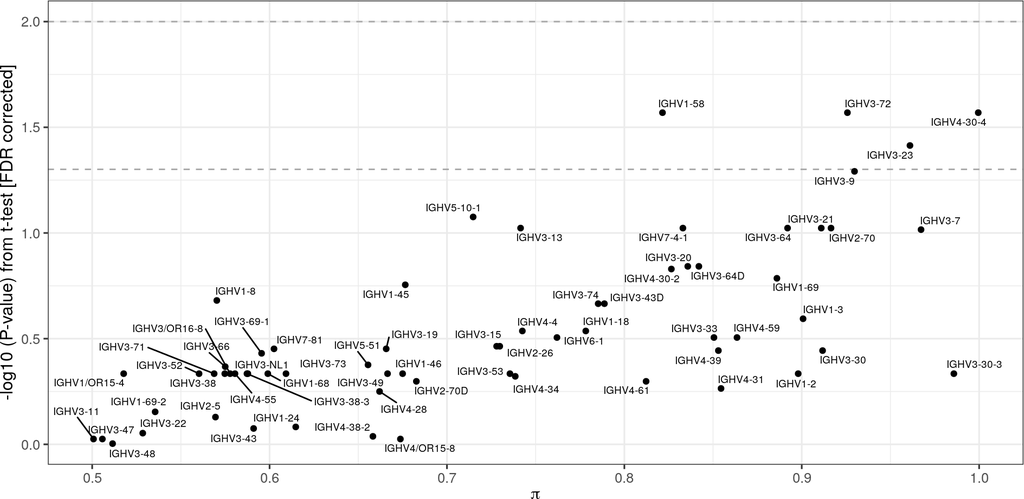

#### 3.1.5.4 Outliers: IGHV1-58 and IGHV3-72 [%]

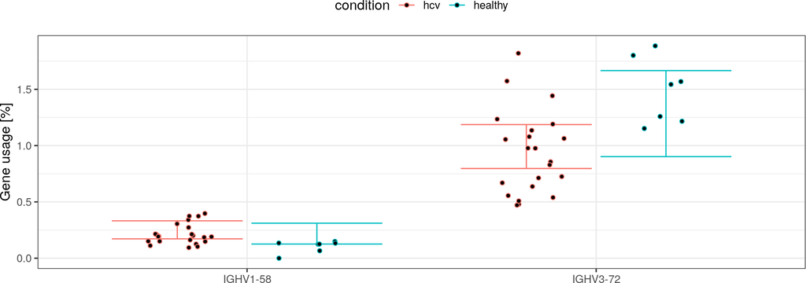

#### 3.1.5.5 Outliers: IGHV1-58 and IGHV3-72 [counts]

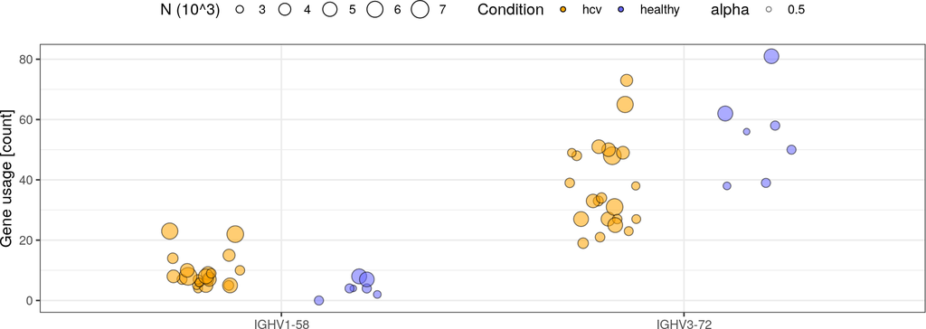

#### 3.1.5.6 Comparison with the Wilcoxon rank-sum test (U-test)

Another popular method for differential gene usage analysis is the nonparametric U-test. Its assumption of expecting equal shape is also not met by our data. Here, we nevertheless compare our results against p-values obtained with a the U-test, which are automatically estimated by IgGeneUsage.

The following figure compares the effect sizes obtained from the Bayesian analysis with the p-values obtained from the U-test. Legend:

- y-axis: FDR-corrected p-value shown on -log10 scale. Dashed lines represent the significance levels of 0.05 and 0.01.
- x-axis: probability of differential gene usage
- color: effect size excludes null.

We observe similar results as in the case of the t-test. We can see that the U-test is under-powered to detect statistically significant differences in gene usage. This is both due to the low sample size and also due to the correction for multiple comparison.

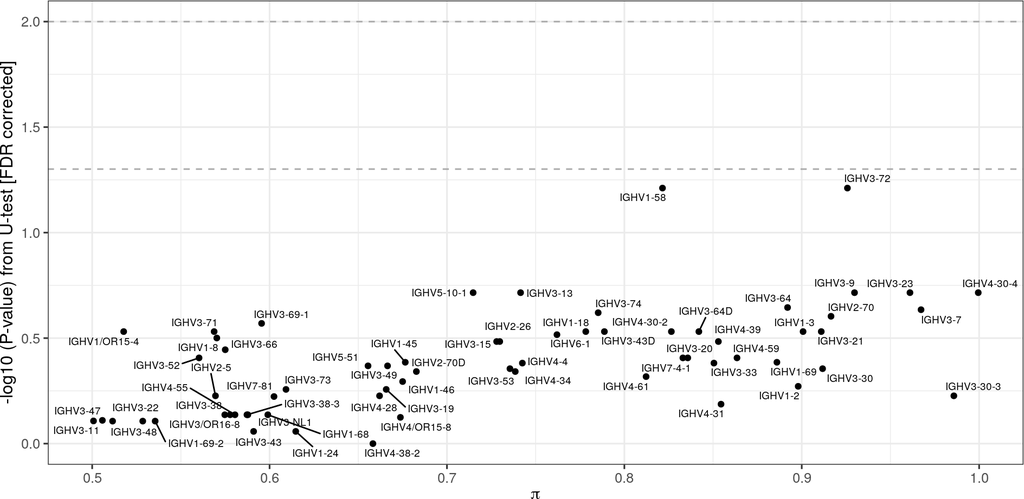

## 3.2 Case Study II

A small example database subset from study evaluating vaccine-induced changes in B-cell populations . The IGHV family usage is reported in four B-cell populations (samples IgM, IgD, IgG and IgA) across two timepoints (conditions = -1 hour and +7 days). In this case study we investigate the overal effect of the vaccine on the IGHV family usage.

Laserson U and Vigneault F, et al. High-resolution antibody dynamics of vaccine-induced immune responses. Proc Natl Acad Sci USA. 2014 111:4928-33.

### 3.2.1 Input data

| gene_name | sample_id | condition | gene_usage_count |
| --- | --- | --- | --- |
| IGHV1 | -1h_IgA | -1h | 8 |
| IGHV1 | -1h_IgD | -1h | 38 |
| IGHV1 | -1h_IgG | -1h | 7 |
| IGHV1 | -1h_IgM | -1h | 110 |
| IGHV1 | +7d_IgA | +7d | 2 |
| IGHV1 | +7d_IgD | +7d | 7 |

### 3.2.2 Data visualization

Lets look at the input data with ggplot2.

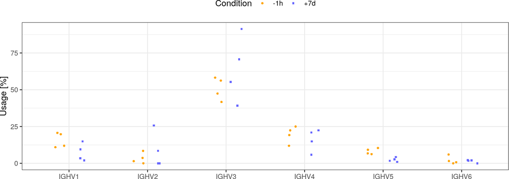

### 3.2.3 Analysis with IgGeneUsage

This is the main method of IgGeneUsage for differential gene usage.

### 3.2.4 Model checking

#### 3.2.4.1 Checking MCMC sampling

- divergences, tree-depth, energy

```
FALSE
FALSE Divergences:
FALSE
FALSE Tree depth:
FALSE
FALSE Energy:
```

- Rhat and Neff

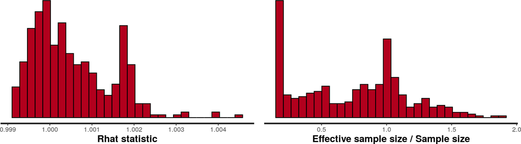

#### 3.2.4.2 Repertoire-specific PPC

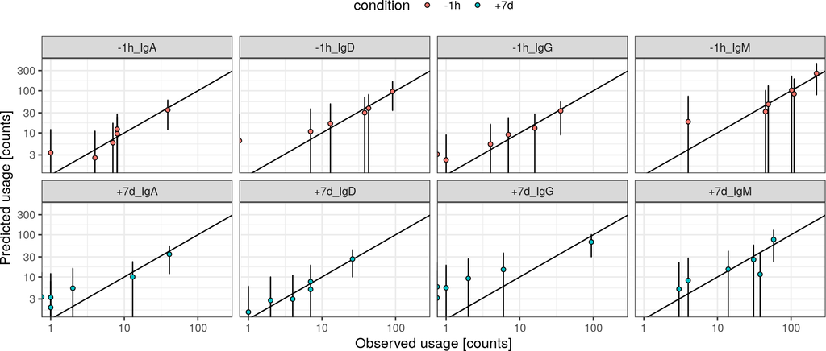

#### 3.2.4.3 Gene-specific PPC

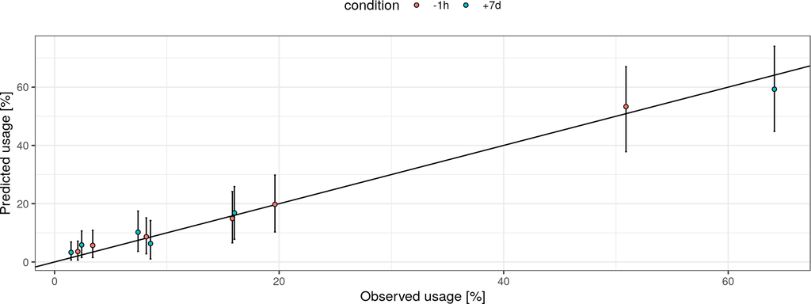

#### 3.2.4.4 Leave-one-out comparison

- with R-package loo

```
FALSE
FALSE Computed from 4000 by 48 log-likelihood matrix
FALSE
FALSE          Estimate   SE
FALSE elpd_loo   -162.3  9.9
FALSE p_loo        14.7  3.4
FALSE looic       324.7 19.9
FALSE ------
FALSE Monte Carlo SE of elpd_loo is NA.
FALSE
FALSE Pareto k diagnostic values:
FALSE                          Count Pct.    Min. n_eff
FALSE (-Inf, 0.5]   (good)     27    56.2%   1520
FALSE  (0.5, 0.7]   (ok)       17    35.4%   105
FALSE    (0.7, 1]   (bad)       4     8.3%   289
FALSE    (1, Inf)   (very bad)  0     0.0%   <NA>
FALSE See help('pareto-k-diagnostic') for details.
```

### 3.2.5 Results

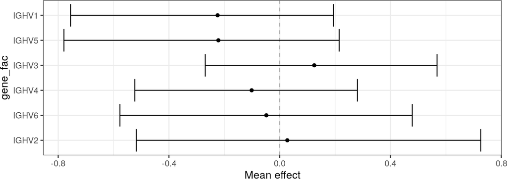

#### 3.2.5.1 Comparison with the t-test

We again compare the effect sizes obtained from the Bayesian analysis with the p-values obtained from the t-test. Legend:

- y-axis: FDR-corrected p-value shown on -log10 scale. Dashed lines represent the significance levels of 0.05 and 0.01.
- x-axis: probability of differential gene usage
- color: effect size excludes null.

We can notice one deviation between the two tests, namely the gene family IGHV5. Lets inspect this gene more closely.

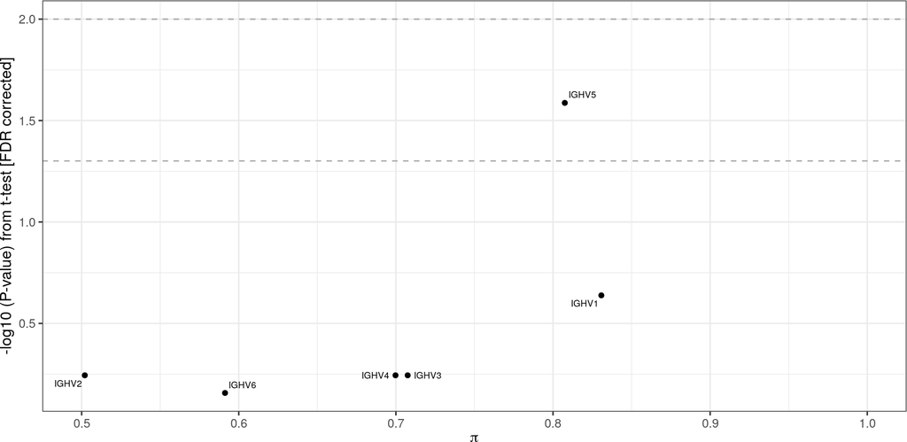

#### 3.2.5.2 Outliers: IGHV5

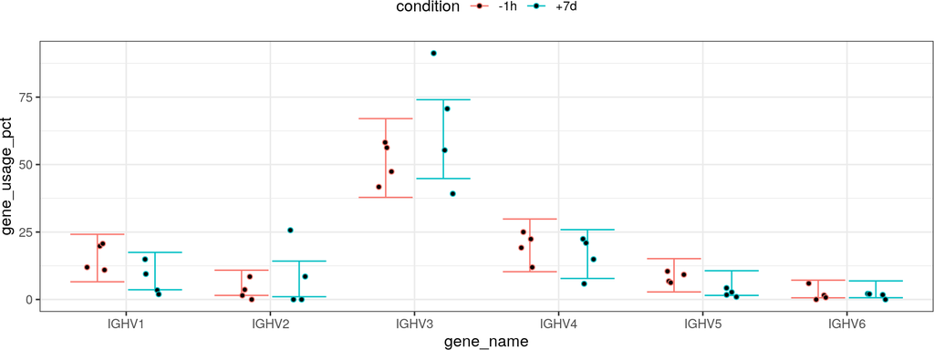

#### 3.2.5.3 Outliers: IGHV5 (original data)

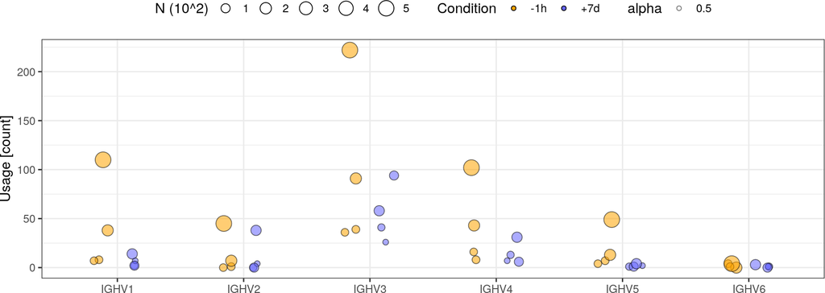

#### 3.2.5.4 Comparison with the Wilcoxon rank-sum test (U-test)

We again compare the effect sizes obtained from the Bayesian analysis with the p-values obtained from the U-test. Legend:

- y-axis: FDR-corrected p-value shown on -log10 scale. Dashed lines represent the significance levels of 0.05 and 0.01.
- x-axis: probability of differential gene usage
- color: effect size excludes null.

Both methods report no significant differential gene usages.

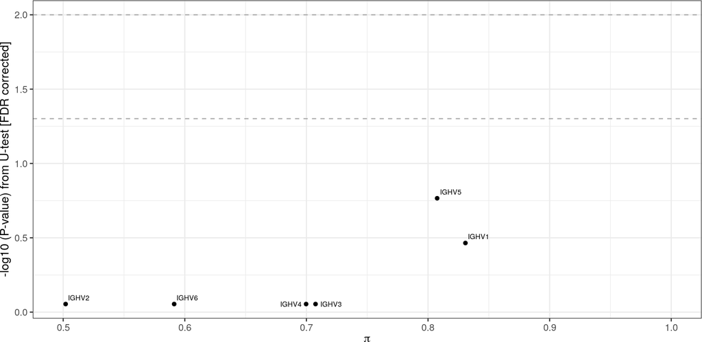

## 3.3 Case Study III

The main purpose of using IgGeneUsage is to evaluate differential gene usage. However, the tool can be used to analyze different repertoire properties such as differential CDR3-sequence charge and length usage. In principle, all tasks that fall under the scope of binomial regression can be tackled by IgGeneUsage.

https://vdjdb.cdr3.net/

We consider the amino acids K, R and H as +1 charged, while D and E as -1 charged. We computed the net charge of a CDR3 sequence by adding up the individual charges. We consider the different sources (publications) as different subjects (repertoires).

### 3.3.1 Input data

| sample_id | condition | gene_name | gene_usage_count |
| --- | --- | --- | --- |
| https://github.com/antigenomics/vdjdb-db/issues/267_InfluenzaA | InfluenzaA | -5 | 0 |
| https://github.com/antigenomics/vdjdb-db/issues/267_InfluenzaA | InfluenzaA | -4 | 0 |
| https://github.com/antigenomics/vdjdb-db/issues/267_InfluenzaA | InfluenzaA | -3 | 0 |
| https://github.com/antigenomics/vdjdb-db/issues/267_InfluenzaA | InfluenzaA | -2 | 6 |
| https://github.com/antigenomics/vdjdb-db/issues/267_InfluenzaA | InfluenzaA | -1 | 46 |
| https://github.com/antigenomics/vdjdb-db/issues/267_InfluenzaA | InfluenzaA | 0 | 164 |

### 3.3.2 Data visualization

Lets look at the input data with ggplot2.

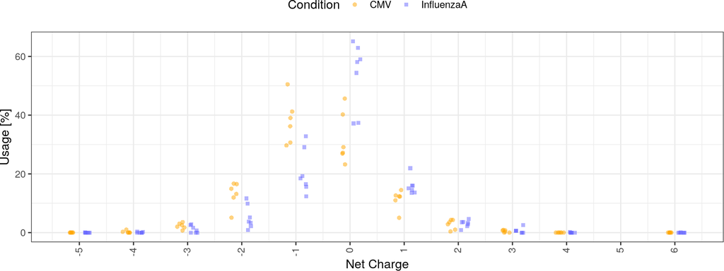

### 3.3.3 Analysis with IgGeneUsage

### 3.3.4 Model checking

#### 3.3.4.1 Checking MCMC sampling

- divergences, tree-depth, energy

```
FALSE
FALSE Divergences:
FALSE
FALSE Tree depth:
FALSE
FALSE Energy:
```

- Rhat and Neff

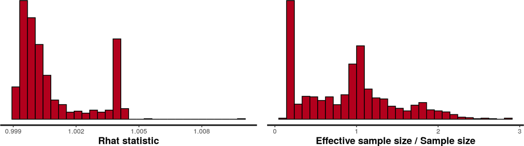

#### 3.3.4.2 Repertoire-specific PPC

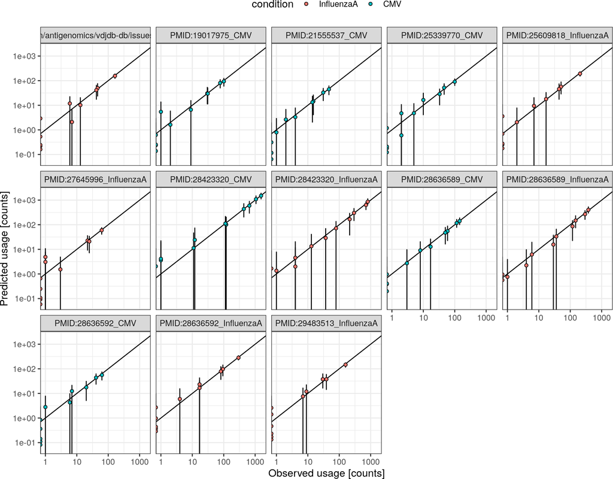

#### 3.3.4.3 Net-charge specific PPC

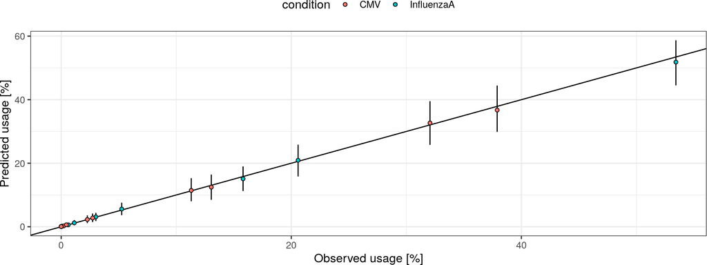

#### 3.3.4.4 Leave-one-out comparison

- with R-package loo

```
FALSE
FALSE Computed from 4000 by 143 log-likelihood matrix
FALSE
FALSE          Estimate   SE
FALSE elpd_loo   -381.7 24.3
FALSE p_loo        48.8  4.5
FALSE looic       763.4 48.6
FALSE ------
FALSE Monte Carlo SE of elpd_loo is NA.
FALSE
FALSE Pareto k diagnostic values:
FALSE                          Count Pct.    Min. n_eff
FALSE (-Inf, 0.5]   (good)     80    55.9%   603
FALSE  (0.5, 0.7]   (ok)       36    25.2%   166
FALSE    (0.7, 1]   (bad)      25    17.5%   49
FALSE    (1, Inf)   (very bad)  2     1.4%   14
FALSE See help('pareto-k-diagnostic') for details.
```

### 3.3.5 Results

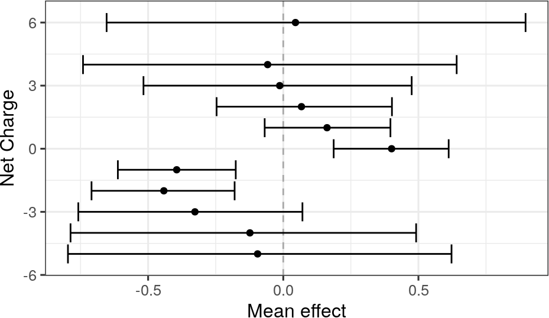

#### 3.3.5.1 Comparison with the t-test

We again compare the effect sizes obtained from the Bayesian analysis with the p-values obtained from the t-test. Legend:

- y-axis: FDR-corrected p-value shown on -log10 scale. Dashed lines represent the significance levels of 0.05 and 0.01.
- x-axis: probability of differential usage
- color: effect size excludes null.

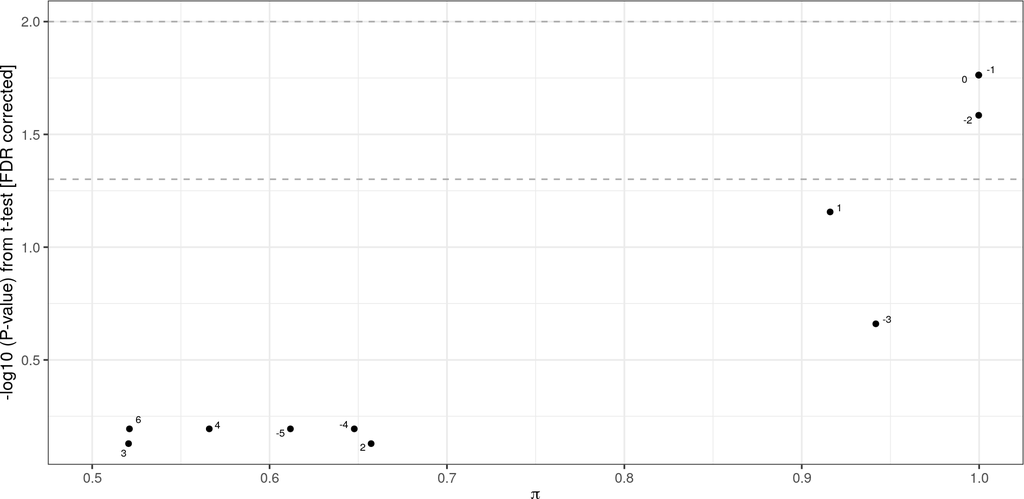

#### 3.3.5.2 Comparison with the Wilcoxon rank-sum test (U-test)

We again compare the effect sizes obtained from the Bayesian analysis with the p-values obtained from the U-test. Legend:

- y-axis: FDR-corrected p-value shown on -log10 scale. Dashed lines represent the significance levels of 0.05 and 0.01.
- x-axis: probability of differential usage
- color: effect size excludes null.

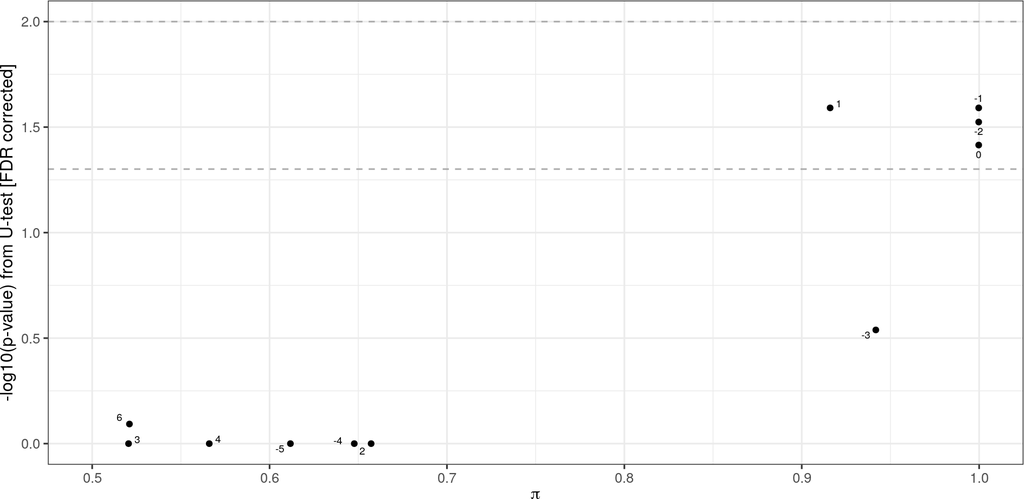